# Risk Factor Analysis

## Outcome Variable

**Outcome Variable:** sstunted

## Predictor Variables

**Intervention Variable:** enstunt

**Adjustment Set:**

- arm
- sex
- W_mage
- meducyrs
- feducyrs
- hhwealth_quart
- vagbrth
- W_nrooms
- brthmon
- W_parity
- impfloor
- impsan
- safeh20
- delta_W_mage
- delta_meducyrs
- delta_feducyrs
- delta_hhwealth_quart
- delta_vagbrth
- delta_W_nrooms
- delta_brthmon
- delta_W_parity
- delta_impfloor
- delta_impsan
- delta_safeh20

## Stratifying Variables

The analysis was stratified on these variable(s):

- agecat
- studyid
- country

## Data Summary

| agecat | studyid | country | enstunt | sstunted | n_cell | n |
| --- | --- | --- | --- | --- | --- | --- |
| Birth | ki0047075b-MAL-ED | BANGLADESH | 0 | 0 | 210 | 257 |
| Birth | ki0047075b-MAL-ED | BANGLADESH | 0 | 1 | 0 | 257 |
| Birth | ki0047075b-MAL-ED | BANGLADESH | 1 | 0 | 38 | 257 |
| Birth | ki0047075b-MAL-ED | BANGLADESH | 1 | 1 | 9 | 257 |
| Birth | ki0047075b-MAL-ED | BRAZIL | 0 | 0 | 170 | 191 |
| Birth | ki0047075b-MAL-ED | BRAZIL | 0 | 1 | 0 | 191 |
| Birth | ki0047075b-MAL-ED | BRAZIL | 1 | 0 | 13 | 191 |
| Birth | ki0047075b-MAL-ED | BRAZIL | 1 | 1 | 8 | 191 |
| Birth | ki0047075b-MAL-ED | INDIA | 0 | 0 | 173 | 206 |
| Birth | ki0047075b-MAL-ED | INDIA | 0 | 1 | 0 | 206 |
| Birth | ki0047075b-MAL-ED | INDIA | 1 | 0 | 26 | 206 |
| Birth | ki0047075b-MAL-ED | INDIA | 1 | 1 | 7 | 206 |
| Birth | ki0047075b-MAL-ED | NEPAL | 0 | 0 | 155 | 173 |
| Birth | ki0047075b-MAL-ED | NEPAL | 0 | 1 | 0 | 173 |
| Birth | ki0047075b-MAL-ED | NEPAL | 1 | 0 | 12 | 173 |
| Birth | ki0047075b-MAL-ED | NEPAL | 1 | 1 | 6 | 173 |
| Birth | ki0047075b-MAL-ED | PERU | 0 | 0 | 253 | 287 |
| Birth | ki0047075b-MAL-ED | PERU | 0 | 1 | 0 | 287 |
| Birth | ki0047075b-MAL-ED | PERU | 1 | 0 | 26 | 287 |
| Birth | ki0047075b-MAL-ED | PERU | 1 | 1 | 8 | 287 |
| Birth | ki0047075b-MAL-ED | SOUTH AFRICA | 0 | 0 | 234 | 262 |
| Birth | ki0047075b-MAL-ED | SOUTH AFRICA | 0 | 1 | 0 | 262 |
| Birth | ki0047075b-MAL-ED | SOUTH AFRICA | 1 | 0 | 26 | 262 |
| Birth | ki0047075b-MAL-ED | SOUTH AFRICA | 1 | 1 | 2 | 262 |
| Birth | ki0047075b-MAL-ED | TANZANIA, UNITED REPUBLIC OF | 0 | 0 | 105 | 123 |
| Birth | ki0047075b-MAL-ED | TANZANIA, UNITED REPUBLIC OF | 0 | 1 | 0 | 123 |
| Birth | ki0047075b-MAL-ED | TANZANIA, UNITED REPUBLIC OF | 1 | 0 | 12 | 123 |
| Birth | ki0047075b-MAL-ED | TANZANIA, UNITED REPUBLIC OF | 1 | 1 | 6 | 123 |
| Birth | ki1000108-CMC-V-BCS-2002 | INDIA | 0 | 0 | 74 | 90 |
| Birth | ki1000108-CMC-V-BCS-2002 | INDIA | 0 | 1 | 0 | 90 |

[output cut: 314 more lines]

The following strata were considered:

- agecat: 24 months, studyid: ki0047075b-MAL-ED, country: BANGLADESH
- agecat: 24 months, studyid: ki0047075b-MAL-ED, country: BRAZIL
- agecat: 24 months, studyid: ki0047075b-MAL-ED, country: INDIA
- agecat: 24 months, studyid: ki0047075b-MAL-ED, country: NEPAL
- agecat: 24 months, studyid: ki0047075b-MAL-ED, country: PERU
- agecat: 24 months, studyid: ki0047075b-MAL-ED, country: SOUTH AFRICA
- agecat: 24 months, studyid: ki0047075b-MAL-ED, country: TANZANIA, UNITED REPUBLIC OF
- agecat: 24 months, studyid: ki1000108-CMC-V-BCS-2002, country: INDIA
- agecat: 24 months, studyid: ki1000108-IRC, country: INDIA
- agecat: 24 months, studyid: ki1017093-NIH-Birth, country: BANGLADESH
- agecat: 24 months, studyid: ki1017093b-PROVIDE, country: BANGLADESH
- agecat: 24 months, studyid: ki1017093c-NIH-Crypto, country: BANGLADESH
- agecat: 24 months, studyid: ki1066203-TanzaniaChild2, country: TANZANIA, UNITED REPUBLIC OF
- agecat: 24 months, studyid: ki1101329-Keneba, country: GAMBIA
- agecat: 24 months, studyid: ki1113344-GMS-Nepal, country: NEPAL
- agecat: 24 months, studyid: ki1114097-CMIN, country: BANGLADESH
- agecat: 24 months, studyid: ki1114097-CMIN, country: GUINEA-BISSAU
- agecat: 24 months, studyid: ki1114097-CMIN, country: PERU
- agecat: 24 months, studyid: ki1114097-CONTENT, country: PERU
- agecat: 24 months, studyid: ki1119695-PROBIT, country: BELARUS
- agecat: 24 months, studyid: ki1126311-ZVITAMBO, country: ZIMBABWE
- agecat: 24 months, studyid: ki1135781-COHORTS, country: GUATEMALA
- agecat: 24 months, studyid: ki1135781-COHORTS, country: INDIA
- agecat: 24 months, studyid: ki1135781-COHORTS, country: PHILIPPINES
- agecat: 24 months, studyid: ki1148112-LCNI-5, country: MALAWI
- agecat: 24 months, studyid: kiGH5241-JiVitA-3, country: BANGLADESH
- agecat: 24 months, studyid: kiGH5241-JiVitA-4, country: BANGLADESH
- agecat: 6 months, studyid: ki0047075b-MAL-ED, country: BANGLADESH
- agecat: 6 months, studyid: ki0047075b-MAL-ED, country: BRAZIL
- agecat: 6 months, studyid: ki0047075b-MAL-ED, country: INDIA
- agecat: 6 months, studyid: ki0047075b-MAL-ED, country: NEPAL
- agecat: 6 months, studyid: ki0047075b-MAL-ED, country: PERU
- agecat: 6 months, studyid: ki0047075b-MAL-ED, country: SOUTH AFRICA
- agecat: 6 months, studyid: ki0047075b-MAL-ED, country: TANZANIA, UNITED REPUBLIC OF
- agecat: 6 months, studyid: ki1000108-CMC-V-BCS-2002, country: INDIA
- agecat: 6 months, studyid: ki1000108-IRC, country: INDIA
- agecat: 6 months, studyid: ki1000109-EE, country: PAKISTAN
- agecat: 6 months, studyid: ki1000109-ResPak, country: PAKISTAN
- agecat: 6 months, studyid: ki1000304b-SAS-CompFeed, country: INDIA
- agecat: 6 months, studyid: ki1000304b-SAS-FoodSuppl, country: INDIA
- agecat: 6 months, studyid: ki1017093-NIH-Birth, country: BANGLADESH
- agecat: 6 months, studyid: ki1017093b-PROVIDE, country: BANGLADESH
- agecat: 6 months, studyid: ki1017093c-NIH-Crypto, country: BANGLADESH
- agecat: 6 months, studyid: ki1066203-TanzaniaChild2, country: TANZANIA, UNITED REPUBLIC OF
- agecat: 6 months, studyid: ki1101329-Keneba, country: GAMBIA
- agecat: 6 months, studyid: ki1112895-Guatemala BSC, country: GUATEMALA
- agecat: 6 months, studyid: ki1113344-GMS-Nepal, country: NEPAL
- agecat: 6 months, studyid: ki1114097-CMIN, country: BANGLADESH
- agecat: 6 months, studyid: ki1114097-CMIN, country: BRAZIL
- agecat: 6 months, studyid: ki1114097-CMIN, country: GUINEA-BISSAU
- agecat: 6 months, studyid: ki1114097-CMIN, country: PERU
- agecat: 6 months, studyid: ki1114097-CONTENT, country: PERU
- agecat: 6 months, studyid: ki1119695-PROBIT, country: BELARUS
- agecat: 6 months, studyid: ki1126311-ZVITAMBO, country: ZIMBABWE
- agecat: 6 months, studyid: ki1135781-COHORTS, country: GUATEMALA
- agecat: 6 months, studyid: ki1135781-COHORTS, country: INDIA
- agecat: 6 months, studyid: ki1135781-COHORTS, country: PHILIPPINES
- agecat: 6 months, studyid: ki1148112-LCNI-5, country: MALAWI
- agecat: 6 months, studyid: kiGH5241-JiVitA-3, country: BANGLADESH
- agecat: 6 months, studyid: kiGH5241-JiVitA-4, country: BANGLADESH
- agecat: Birth, studyid: ki0047075b-MAL-ED, country: BANGLADESH
- agecat: Birth, studyid: ki0047075b-MAL-ED, country: BRAZIL
- agecat: Birth, studyid: ki0047075b-MAL-ED, country: INDIA
- agecat: Birth, studyid: ki0047075b-MAL-ED, country: NEPAL
- agecat: Birth, studyid: ki0047075b-MAL-ED, country: PERU
- agecat: Birth, studyid: ki0047075b-MAL-ED, country: SOUTH AFRICA
- agecat: Birth, studyid: ki0047075b-MAL-ED, country: TANZANIA, UNITED REPUBLIC OF
- agecat: Birth, studyid: ki1000108-CMC-V-BCS-2002, country: INDIA
- agecat: Birth, studyid: ki1000108-IRC, country: INDIA
- agecat: Birth, studyid: ki1000109-EE, country: PAKISTAN
- agecat: Birth, studyid: ki1000109-ResPak, country: PAKISTAN
- agecat: Birth, studyid: ki1000304b-SAS-CompFeed, country: INDIA
- agecat: Birth, studyid: ki1017093-NIH-Birth, country: BANGLADESH
- agecat: Birth, studyid: ki1017093c-NIH-Crypto, country: BANGLADESH
- agecat: Birth, studyid: ki1101329-Keneba, country: GAMBIA
- agecat: Birth, studyid: ki1114097-CMIN, country: BANGLADESH
- agecat: Birth, studyid: ki1114097-CMIN, country: BRAZIL
- agecat: Birth, studyid: ki1114097-CMIN, country: PERU
- agecat: Birth, studyid: ki1114097-CONTENT, country: PERU
- agecat: Birth, studyid: ki1119695-PROBIT, country: BELARUS
- agecat: Birth, studyid: ki1126311-ZVITAMBO, country: ZIMBABWE
- agecat: Birth, studyid: ki1135781-COHORTS, country: GUATEMALA
- agecat: Birth, studyid: ki1135781-COHORTS, country: INDIA
- agecat: Birth, studyid: ki1135781-COHORTS, country: PHILIPPINES
- agecat: Birth, studyid: kiGH5241-JiVitA-3, country: BANGLADESH
- agecat: Birth, studyid: kiGH5241-JiVitA-4, country: BANGLADESH

### Dropped Strata

Some strata were dropped due to rare outcomes:

- agecat: Birth, studyid: ki0047075b-MAL-ED, country: BANGLADESH
- agecat: Birth, studyid: ki0047075b-MAL-ED, country: BRAZIL
- agecat: Birth, studyid: ki0047075b-MAL-ED, country: INDIA
- agecat: Birth, studyid: ki0047075b-MAL-ED, country: NEPAL
- agecat: Birth, studyid: ki0047075b-MAL-ED, country: PERU
- agecat: Birth, studyid: ki0047075b-MAL-ED, country: SOUTH AFRICA
- agecat: Birth, studyid: ki0047075b-MAL-ED, country: TANZANIA, UNITED REPUBLIC OF
- agecat: Birth, studyid: ki1000108-CMC-V-BCS-2002, country: INDIA
- agecat: Birth, studyid: ki1000108-IRC, country: INDIA
- agecat: Birth, studyid: ki1000109-EE, country: PAKISTAN
- agecat: Birth, studyid: ki1000109-ResPak, country: PAKISTAN
- agecat: Birth, studyid: ki1000304b-SAS-CompFeed, country: INDIA
- agecat: Birth, studyid: ki1017093-NIH-Birth, country: BANGLADESH
- agecat: Birth, studyid: ki1017093c-NIH-Crypto, country: BANGLADESH
- agecat: Birth, studyid: ki1101329-Keneba, country: GAMBIA
- agecat: Birth, studyid: ki1114097-CMIN, country: BANGLADESH
- agecat: Birth, studyid: ki1114097-CMIN, country: BRAZIL
- agecat: Birth, studyid: ki1114097-CMIN, country: PERU
- agecat: Birth, studyid: ki1114097-CONTENT, country: PERU
- agecat: Birth, studyid: ki1119695-PROBIT, country: BELARUS
- agecat: Birth, studyid: ki1126311-ZVITAMBO, country: ZIMBABWE
- agecat: Birth, studyid: ki1135781-COHORTS, country: GUATEMALA
- agecat: Birth, studyid: ki1135781-COHORTS, country: INDIA
- agecat: Birth, studyid: ki1135781-COHORTS, country: PHILIPPINES
- agecat: Birth, studyid: kiGH5241-JiVitA-3, country: BANGLADESH
- agecat: Birth, studyid: kiGH5241-JiVitA-4, country: BANGLADESH
- agecat: 6 months, studyid: ki0047075b-MAL-ED, country: BANGLADESH
- agecat: 6 months, studyid: ki0047075b-MAL-ED, country: BRAZIL
- agecat: 6 months, studyid: ki0047075b-MAL-ED, country: INDIA
- agecat: 6 months, studyid: ki0047075b-MAL-ED, country: NEPAL
- agecat: 6 months, studyid: ki0047075b-MAL-ED, country: PERU
- agecat: 6 months, studyid: ki0047075b-MAL-ED, country: SOUTH AFRICA
- agecat: 6 months, studyid: ki1000304b-SAS-FoodSuppl, country: INDIA
- agecat: 6 months, studyid: ki1112895-Guatemala BSC, country: GUATEMALA
- agecat: 6 months, studyid: ki1114097-CMIN, country: BANGLADESH
- agecat: 6 months, studyid: ki1114097-CMIN, country: BRAZIL
- agecat: 6 months, studyid: ki1114097-CMIN, country: GUINEA-BISSAU
- agecat: 6 months, studyid: ki1114097-CMIN, country: PERU
- agecat: 6 months, studyid: ki1114097-CONTENT, country: PERU
- agecat: 6 months, studyid: ki1148112-LCNI-5, country: MALAWI
- agecat: 24 months, studyid: ki0047075b-MAL-ED, country: BRAZIL
- agecat: 24 months, studyid: ki0047075b-MAL-ED, country: NEPAL
- agecat: 24 months, studyid: ki0047075b-MAL-ED, country: SOUTH AFRICA
- agecat: 24 months, studyid: ki1066203-TanzaniaChild2, country: TANZANIA, UNITED REPUBLIC OF
- agecat: 24 months, studyid: ki1114097-CONTENT, country: PERU
- agecat: 24 months, studyid: ki1119695-PROBIT, country: BELARUS

## Methods Detail

We’re interested in the causal parameters $E[Y_a]$ for all values of $a \in \mathcal{A}$. These parameters represent the mean outcome if, possibly contrary to fact, we intervened to set all units to have $A=a$. Under the randomization and positivity assumptions, these are identified by the statistical parameters $\psi_a=E_W[E_{Y|A,W}(Y|A=a,W)]$. In addition, we’re interested in the mean of $Y$, $E[Y]$ under no intervention (the observed mean). We will estimate these parameters by using SuperLearner to fit the relevant likelihood factors – $E_{Y|A,W}(Y|A=a,W)$ and $p(A=a|W)$, and then updating our likelihood fit using a joint TMLE.

For unadjusted analyses ($W=\{\}$), initial likelihoods were estimated using Lrnr_glm to estimate the simple $E(Y|A)$ and Lrnr_mean to estimate $p(A)$. For adjusted analyses, a small library containing Lrnr_glmnet, Lrnr_xgboost, and Lrnr_mean was used.

Having estimated these parameters, we will then use the delta method to estimate relative risks and attributable risks relative to a prespecified baseline level of $A$.

# Results Detail

## Results Plots

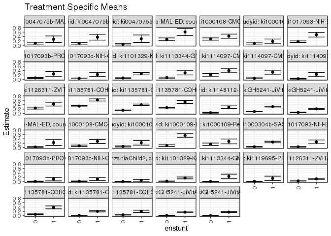

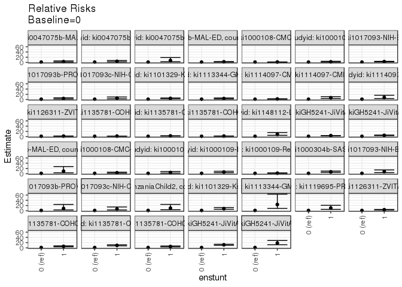

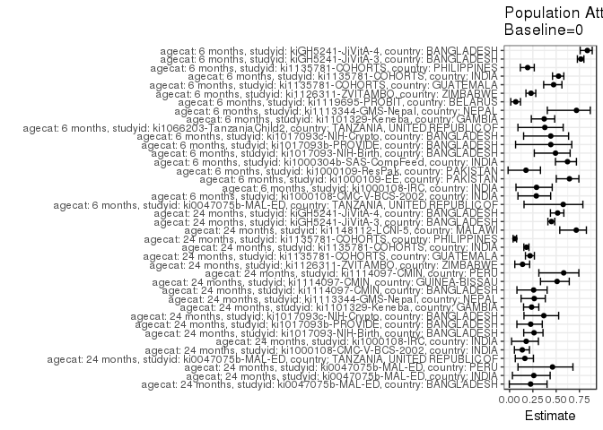

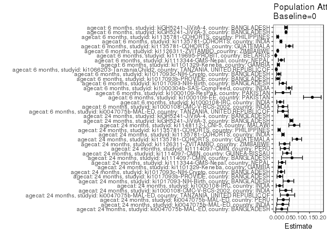

## Results Table

### Parameter: TSM

| agecat | studyid | country | intervention_level | baseline_level | estimate | ci_lower | ci_upper |
| --- | --- | --- | --- | --- | --- | --- | --- |
| 6 months | ki0047075b-MAL-ED | TANZANIA, UNITED REPUBLIC OF | 0 | NA | 0.0240385 | 0.0031807 | 0.0448962 |
| 6 months | ki0047075b-MAL-ED | TANZANIA, UNITED REPUBLIC OF | 1 | NA | 0.2307692 | 0.0982698 | 0.3632687 |
| 6 months | ki1000108-CMC-V-BCS-2002 | INDIA | 0 | NA | 0.0811647 | 0.0501236 | 0.1122059 |
| 6 months | ki1000108-CMC-V-BCS-2002 | INDIA | 1 | NA | 0.2834063 | 0.1885732 | 0.3782394 |
| 6 months | ki1000108-IRC | INDIA | 0 | NA | 0.0506331 | 0.0279226 | 0.0733436 |
| 6 months | ki1000108-IRC | INDIA | 1 | NA | 0.2223926 | 0.1131275 | 0.3316577 |
| 6 months | ki1000109-EE | PAKISTAN | 0 | NA | 0.0902444 | 0.0547378 | 0.1257511 |
| 6 months | ki1000109-EE | PAKISTAN | 1 | NA | 0.5527400 | 0.4725643 | 0.6329157 |
| 6 months | ki1000109-ResPak | PAKISTAN | 0 | NA | 0.1542783 | 0.1005026 | 0.2080541 |
| 6 months | ki1000109-ResPak | PAKISTAN | 1 | NA | 0.2813080 | 0.1701576 | 0.3924584 |
| 6 months | ki1000304b-SAS-CompFeed | INDIA | 0 | NA | 0.0362425 | 0.0217000 | 0.0507850 |
| 6 months | ki1000304b-SAS-CompFeed | INDIA | 1 | NA | 0.2539868 | 0.2183290 | 0.2896447 |
| 6 months | ki1017093-NIH-Birth | BANGLADESH | 0 | NA | 0.0330443 | 0.0166377 | 0.0494509 |
| 6 months | ki1017093-NIH-Birth | BANGLADESH | 1 | NA | 0.2604811 | 0.1723426 | 0.3486197 |
| 6 months | ki1017093b-PROVIDE | BANGLADESH | 0 | NA | 0.0133843 | 0.0035274 | 0.0232413 |
| 6 months | ki1017093b-PROVIDE | BANGLADESH | 1 | NA | 0.1166667 | 0.0353685 | 0.1979649 |
| 6 months | ki1017093c-NIH-Crypto | BANGLADESH | 0 | NA | 0.0179387 | 0.0074225 | 0.0284549 |
| 6 months | ki1017093c-NIH-Crypto | BANGLADESH | 1 | NA | 0.1178551 | 0.0552982 | 0.1804120 |
| 6 months | ki1066203-TanzaniaChild2 | TANZANIA, UNITED REPUBLIC OF | 0 | NA | 0.0058201 | 0.0023899 | 0.0092503 |
| 6 months | ki1066203-TanzaniaChild2 | TANZANIA, UNITED REPUBLIC OF | 1 | NA | 0.0575540 | 0.0188270 | 0.0962809 |
| 6 months | ki1101329-Keneba | GAMBIA | 0 | NA | 0.0210565 | 0.0145918 | 0.0275212 |
| 6 months | ki1101329-Keneba | GAMBIA | 1 | NA | 0.1710525 | 0.1282013 | 0.2139037 |
| 6 months | ki1113344-GMS-Nepal | NEPAL | 0 | NA | 0.0100040 | 0.0013080 | 0.0186999 |
| 6 months | ki1113344-GMS-Nepal | NEPAL | 1 | NA | 0.2399848 | 0.1349803 | 0.3449893 |
| 6 months | ki1119695-PROBIT | BELARUS | 0 | NA | 0.0143897 | 0.0091533 | 0.0196260 |
| 6 months | ki1119695-PROBIT | BELARUS | 1 | NA | 0.1499408 | 0.0489163 | 0.2509653 |
| 6 months | ki1126311-ZVITAMBO | ZIMBABWE | 0 | NA | 0.0321056 | 0.0281089 | 0.0361024 |
| 6 months | ki1126311-ZVITAMBO | ZIMBABWE | 1 | NA | 0.1275247 | 0.1058940 | 0.1491553 |
| 6 months | ki1135781-COHORTS | GUATEMALA | 0 | NA | 0.0680002 | 0.0506827 | 0.0853176 |
| 6 months | ki1135781-COHORTS | GUATEMALA | 1 | NA | 0.3836237 | 0.3161715 | 0.4510759 |
| 6 months | ki1135781-COHORTS | INDIA | 0 | NA | 0.0215030 | 0.0178598 | 0.0251462 |
| 6 months | ki1135781-COHORTS | INDIA | 1 | NA | 0.2016995 | 0.1748025 | 0.2285966 |
| 6 months | ki1135781-COHORTS | PHILIPPINES | 0 | NA | 0.0392851 | 0.0317550 | 0.0468152 |
| 6 months | ki1135781-COHORTS | PHILIPPINES | 1 | NA | 0.1992788 | 0.1444501 | 0.2541074 |
| 6 months | kiGH5241-JiVitA-3 | BANGLADESH | 0 | NA | 0.0142128 | 0.0118179 | 0.0166078 |
| 6 months | kiGH5241-JiVitA-3 | BANGLADESH | 1 | NA | 0.1649119 | 0.1547925 | 0.1750313 |
| 6 months | kiGH5241-JiVitA-4 | BANGLADESH | 0 | NA | 0.0091753 | 0.0053710 | 0.0129796 |
| 6 months | kiGH5241-JiVitA-4 | BANGLADESH | 1 | NA | 0.1674669 | 0.1468571 | 0.1880768 |
| 24 months | ki0047075b-MAL-ED | BANGLADESH | 0 | NA | 0.0949721 | 0.0519217 | 0.1380225 |
| 24 months | ki0047075b-MAL-ED | BANGLADESH | 1 | NA | 0.2727273 | 0.1204165 | 0.4250381 |
| 24 months | ki0047075b-MAL-ED | INDIA | 0 | NA | 0.0912449 | 0.0504015 | 0.1320882 |
| 24 months | ki0047075b-MAL-ED | INDIA | 1 | NA | 0.3702718 | 0.2356385 | 0.5049052 |
| 24 months | ki0047075b-MAL-ED | PERU | 0 | NA | 0.0402299 | 0.0109604 | 0.0694993 |
| 24 months | ki0047075b-MAL-ED | PERU | 1 | NA | 0.2962963 | 0.1236301 | 0.4689625 |
| 24 months | ki0047075b-MAL-ED | TANZANIA, UNITED REPUBLIC OF | 0 | NA | 0.2694209 | 0.2047368 | 0.3341050 |
| 24 months | ki0047075b-MAL-ED | TANZANIA, UNITED REPUBLIC OF | 1 | NA | 0.6075256 | 0.4490185 | 0.7660326 |
| 24 months | ki1000108-CMC-V-BCS-2002 | INDIA | 0 | NA | 0.2855205 | 0.2345200 | 0.3365210 |
| 24 months | ki1000108-CMC-V-BCS-2002 | INDIA | 1 | NA | 0.4151784 | 0.3210297 | 0.5093270 |
| 24 months | ki1000108-IRC | INDIA | 0 | NA | 0.0823725 | 0.0540252 | 0.1107198 |
| 24 months | ki1000108-IRC | INDIA | 1 | NA | 0.1753385 | 0.0670825 | 0.2835944 |
| 24 months | ki1017093-NIH-Birth | BANGLADESH | 0 | NA | 0.1598490 | 0.1217192 | 0.1979788 |
| 24 months | ki1017093-NIH-Birth | BANGLADESH | 1 | NA | 0.4817480 | 0.3731001 | 0.5903960 |
| 24 months | ki1017093b-PROVIDE | BANGLADESH | 0 | NA | 0.0656644 | 0.0443264 | 0.0870023 |
| 24 months | ki1017093b-PROVIDE | BANGLADESH | 1 | NA | 0.2510688 | 0.1410585 | 0.3610791 |
| 24 months | ki1017093c-NIH-Crypto | BANGLADESH | 0 | NA | 0.0430585 | 0.0242203 | 0.0618968 |
| 24 months | ki1017093c-NIH-Crypto | BANGLADESH | 1 | NA | 0.2215623 | 0.1230571 | 0.3200675 |
| 24 months | ki1101329-Keneba | GAMBIA | 0 | NA | 0.0606349 | 0.0487726 | 0.0724973 |
| 24 months | ki1101329-Keneba | GAMBIA | 1 | NA | 0.2587630 | 0.2031969 | 0.3143291 |
| 24 months | ki1113344-GMS-Nepal | NEPAL | 0 | NA | 0.0795263 | 0.0545492 | 0.1045034 |
| 24 months | ki1113344-GMS-Nepal | NEPAL | 1 | NA | 0.2973654 | 0.2014542 | 0.3932766 |
| 24 months | ki1114097-CMIN | BANGLADESH | 0 | NA | 0.2083233 | 0.1438837 | 0.2727629 |
| 24 months | ki1114097-CMIN | BANGLADESH | 1 | NA | 0.4032101 | 0.3012511 | 0.5051690 |
| 24 months | ki1114097-CMIN | GUINEA-BISSAU | 0 | NA | 0.0488934 | 0.0289476 | 0.0688392 |
| 24 months | ki1114097-CMIN | GUINEA-BISSAU | 1 | NA | 0.3273273 | 0.2359237 | 0.4187310 |
| 24 months | ki1114097-CMIN | PERU | 0 | NA | 0.0293029 | 0.0114308 | 0.0471751 |
| 24 months | ki1114097-CMIN | PERU | 1 | NA | 0.2300854 | 0.1414415 | 0.3187293 |
| 24 months | ki1126311-ZVITAMBO | ZIMBABWE | 0 | NA | 0.2466706 | 0.2026739 | 0.2906674 |
| 24 months | ki1126311-ZVITAMBO | ZIMBABWE | 1 | NA | 0.4278927 | 0.3409088 | 0.5148766 |
| 24 months | ki1135781-COHORTS | GUATEMALA | 0 | NA | 0.3351914 | 0.3017238 | 0.3686590 |
| 24 months | ki1135781-COHORTS | GUATEMALA | 1 | NA | 0.6174631 | 0.5686323 | 0.6662940 |
| 24 months | ki1135781-COHORTS | INDIA | 0 | NA | 0.1486033 | 0.1385026 | 0.1587041 |
| 24 months | ki1135781-COHORTS | INDIA | 1 | NA | 0.3968242 | 0.3614181 | 0.4322304 |
| 24 months | ki1135781-COHORTS | PHILIPPINES | 0 | NA | 0.2657817 | 0.2478076 | 0.2837557 |
| 24 months | ki1135781-COHORTS | PHILIPPINES | 1 | NA | 0.5203849 | 0.4532523 | 0.5875174 |
| 24 months | ki1148112-LCNI-5 | MALAWI | 0 | NA | 0.0328831 | 0.0151486 | 0.0506176 |
| 24 months | ki1148112-LCNI-5 | MALAWI | 1 | NA | 0.2867684 | 0.2264304 | 0.3471064 |
| 24 months | kiGH5241-JiVitA-3 | BANGLADESH | 0 | NA | 0.0857577 | 0.0779001 | 0.0936153 |
| 24 months | kiGH5241-JiVitA-3 | BANGLADESH | 1 | NA | 0.3135156 | 0.2954300 | 0.3316012 |
| 24 months | kiGH5241-JiVitA-4 | BANGLADESH | 0 | NA | 0.0445960 | 0.0362322 | 0.0529597 |
| 24 months | kiGH5241-JiVitA-4 | BANGLADESH | 1 | NA | 0.2104673 | 0.1860326 | 0.2349021 |

### Parameter: E(Y)

| agecat | studyid | country | intervention_level | baseline_level | estimate | ci_lower | ci_upper |
| --- | --- | --- | --- | --- | --- | --- | --- |
| 6 months | ki0047075b-MAL-ED | TANZANIA, UNITED REPUBLIC OF | NA | NA | 0.0566802 | 0.0277850 | 0.0855754 |
| 6 months | ki1000108-CMC-V-BCS-2002 | INDIA | NA | NA | 0.1138211 | 0.0813725 | 0.1462698 |
| 6 months | ki1000108-IRC | INDIA | NA | NA | 0.0712531 | 0.0462303 | 0.0962759 |
| 6 months | ki1000109-EE | PAKISTAN | NA | NA | 0.2526882 | 0.2084696 | 0.2969067 |
| 6 months | ki1000109-ResPak | PAKISTAN | NA | NA | 0.1872340 | 0.1372518 | 0.2372162 |
| 6 months | ki1000304b-SAS-CompFeed | INDIA | NA | NA | 0.0958084 | 0.0774939 | 0.1141229 |
| 6 months | ki1017093-NIH-Birth | BANGLADESH | NA | NA | 0.0651769 | 0.0442802 | 0.0860736 |
| 6 months | ki1017093b-PROVIDE | BANGLADESH | NA | NA | 0.0240137 | 0.0115761 | 0.0364514 |
| 6 months | ki1017093c-NIH-Crypto | BANGLADESH | NA | NA | 0.0321678 | 0.0192256 | 0.0451101 |
| 6 months | ki1066203-TanzaniaChild2 | TANZANIA, UNITED REPUBLIC OF | NA | NA | 0.0093642 | 0.0051724 | 0.0135561 |
| 6 months | ki1101329-Keneba | GAMBIA | NA | NA | 0.0335089 | 0.0257898 | 0.0412279 |
| 6 months | ki1113344-GMS-Nepal | NEPAL | NA | NA | 0.0355240 | 0.0202206 | 0.0508273 |
| 6 months | ki1119695-PROBIT | BELARUS | NA | NA | 0.0154178 | 0.0100323 | 0.0208033 |
| 6 months | ki1126311-ZVITAMBO | ZIMBABWE | NA | NA | 0.0417119 | 0.0374091 | 0.0460146 |
| 6 months | ki1135781-COHORTS | GUATEMALA | NA | NA | 0.1290323 | 0.1078261 | 0.1502384 |
| 6 months | ki1135781-COHORTS | INDIA | NA | NA | 0.0453353 | 0.0404119 | 0.0502586 |
| 6 months | ki1135781-COHORTS | PHILIPPINES | NA | NA | 0.0487445 | 0.0406327 | 0.0568562 |
| 6 months | kiGH5241-JiVitA-3 | BANGLADESH | NA | NA | 0.0606665 | 0.0568133 | 0.0645198 |
| 6 months | kiGH5241-JiVitA-4 | BANGLADESH | NA | NA | 0.0556496 | 0.0487560 | 0.0625432 |
| 24 months | ki0047075b-MAL-ED | BANGLADESH | NA | NA | 0.1226415 | 0.0783812 | 0.1669018 |
| 24 months | ki0047075b-MAL-ED | INDIA | NA | NA | 0.1233480 | 0.0804760 | 0.1662200 |
| 24 months | ki0047075b-MAL-ED | PERU | NA | NA | 0.0746269 | 0.0382069 | 0.1110468 |
| 24 months | ki0047075b-MAL-ED | TANZANIA, UNITED REPUBLIC OF | NA | NA | 0.3224299 | 0.2596598 | 0.3852000 |
| 24 months | ki1000108-CMC-V-BCS-2002 | INDIA | NA | NA | 0.3306452 | 0.2827744 | 0.3785159 |
| 24 months | ki1000108-IRC | INDIA | NA | NA | 0.1002445 | 0.0711031 | 0.1293859 |
| 24 months | ki1017093-NIH-Birth | BANGLADESH | NA | NA | 0.2167832 | 0.1777459 | 0.2558205 |
| 24 months | ki1017093b-PROVIDE | BANGLADESH | NA | NA | 0.0849220 | 0.0621566 | 0.1076874 |
| 24 months | ki1017093c-NIH-Crypto | BANGLADESH | NA | NA | 0.0680934 | 0.0462948 | 0.0898920 |
| 24 months | ki1101329-Keneba | GAMBIA | NA | NA | 0.0794203 | 0.0666566 | 0.0921840 |
| 24 months | ki1113344-GMS-Nepal | NEPAL | NA | NA | 0.1082164 | 0.0809323 | 0.1355005 |
| 24 months | ki1114097-CMIN | BANGLADESH | NA | NA | 0.2809917 | 0.2242434 | 0.3377401 |
| 24 months | ki1114097-CMIN | GUINEA-BISSAU | NA | NA | 0.0998185 | 0.0747668 | 0.1248702 |
| 24 months | ki1114097-CMIN | PERU | NA | NA | 0.0699301 | 0.0457690 | 0.0940911 |
| 24 months | ki1126311-ZVITAMBO | ZIMBABWE | NA | NA | 0.2866521 | 0.2451477 | 0.3281565 |
| 24 months | ki1135781-COHORTS | GUATEMALA | NA | NA | 0.4296365 | 0.4000034 | 0.4592696 |
| 24 months | ki1135781-COHORTS | INDIA | NA | NA | 0.1814607 | 0.1711228 | 0.1917985 |
| 24 months | ki1135781-COHORTS | PHILIPPINES | NA | NA | 0.2817996 | 0.2639639 | 0.2996353 |
| 24 months | ki1148112-LCNI-5 | MALAWI | NA | NA | 0.1157168 | 0.0896385 | 0.1417950 |
| 24 months | kiGH5241-JiVitA-3 | BANGLADESH | NA | NA | 0.1558110 | 0.1470514 | 0.1645706 |
| 24 months | kiGH5241-JiVitA-4 | BANGLADESH | NA | NA | 0.0921436 | 0.0826637 | 0.1016234 |

### Parameter: RR

| agecat | studyid | country | intervention_level | baseline_level | estimate | ci_lower | ci_upper |
| --- | --- | --- | --- | --- | --- | --- | --- |
| 6 months | ki0047075b-MAL-ED | TANZANIA, UNITED REPUBLIC OF | 0 | 0 | 1.000000 | 1.000000 | 1.000000 |
| 6 months | ki0047075b-MAL-ED | TANZANIA, UNITED REPUBLIC OF | 1 | 0 | 9.600000 | 3.391639 | 27.172702 |
| 6 months | ki1000108-CMC-V-BCS-2002 | INDIA | 0 | 0 | 1.000000 | 1.000000 | 1.000000 |
| 6 months | ki1000108-CMC-V-BCS-2002 | INDIA | 1 | 0 | 3.491742 | 2.100809 | 5.803603 |
| 6 months | ki1000108-IRC | INDIA | 0 | 0 | 1.000000 | 1.000000 | 1.000000 |
| 6 months | ki1000108-IRC | INDIA | 1 | 0 | 4.392240 | 2.259727 | 8.537213 |
| 6 months | ki1000109-EE | PAKISTAN | 0 | 0 | 1.000000 | 1.000000 | 1.000000 |
| 6 months | ki1000109-EE | PAKISTAN | 1 | 0 | 6.124920 | 4.029729 | 9.309471 |
| 6 months | ki1000109-ResPak | PAKISTAN | 0 | 0 | 1.000000 | 1.000000 | 1.000000 |
| 6 months | ki1000109-ResPak | PAKISTAN | 1 | 0 | 1.823380 | 1.078937 | 3.081473 |
| 6 months | ki1000304b-SAS-CompFeed | INDIA | 0 | 0 | 1.000000 | 1.000000 | 1.000000 |
| 6 months | ki1000304b-SAS-CompFeed | INDIA | 1 | 0 | 7.007983 | 4.904621 | 10.013376 |
| 6 months | ki1017093-NIH-Birth | BANGLADESH | 0 | 0 | 1.000000 | 1.000000 | 1.000000 |
| 6 months | ki1017093-NIH-Birth | BANGLADESH | 1 | 0 | 7.882793 | 4.330093 | 14.350370 |
| 6 months | ki1017093b-PROVIDE | BANGLADESH | 0 | 0 | 1.000000 | 1.000000 | 1.000000 |
| 6 months | ki1017093b-PROVIDE | BANGLADESH | 1 | 0 | 8.716667 | 3.162480 | 24.025537 |
| 6 months | ki1017093c-NIH-Crypto | BANGLADESH | 0 | 0 | 1.000000 | 1.000000 | 1.000000 |
| 6 months | ki1017093c-NIH-Crypto | BANGLADESH | 1 | 0 | 6.569881 | 2.979260 | 14.487937 |
| 6 months | ki1066203-TanzaniaChild2 | TANZANIA, UNITED REPUBLIC OF | 0 | 0 | 1.000000 | 1.000000 | 1.000000 |
| 6 months | ki1066203-TanzaniaChild2 | TANZANIA, UNITED REPUBLIC OF | 1 | 0 | 9.888816 | 4.042664 | 24.189171 |
| 6 months | ki1101329-Keneba | GAMBIA | 0 | 0 | 1.000000 | 1.000000 | 1.000000 |
| 6 months | ki1101329-Keneba | GAMBIA | 1 | 0 | 8.123495 | 5.472481 | 12.058729 |
| 6 months | ki1113344-GMS-Nepal | NEPAL | 0 | 0 | 1.000000 | 1.000000 | 1.000000 |
| 6 months | ki1113344-GMS-Nepal | NEPAL | 1 | 0 | 23.988983 | 9.083004 | 63.356938 |
| 6 months | ki1119695-PROBIT | BELARUS | 0 | 0 | 1.000000 | 1.000000 | 1.000000 |
| 6 months | ki1119695-PROBIT | BELARUS | 1 | 0 | 10.420022 | 5.195751 | 20.897241 |
| 6 months | ki1126311-ZVITAMBO | ZIMBABWE | 0 | 0 | 1.000000 | 1.000000 | 1.000000 |
| 6 months | ki1126311-ZVITAMBO | ZIMBABWE | 1 | 0 | 3.972032 | 3.219143 | 4.901007 |
| 6 months | ki1135781-COHORTS | GUATEMALA | 0 | 0 | 1.000000 | 1.000000 | 1.000000 |
| 6 months | ki1135781-COHORTS | GUATEMALA | 1 | 0 | 5.641510 | 4.147174 | 7.674296 |
| 6 months | ki1135781-COHORTS | INDIA | 0 | 0 | 1.000000 | 1.000000 | 1.000000 |
| 6 months | ki1135781-COHORTS | INDIA | 1 | 0 | 9.380054 | 7.567136 | 11.627307 |
| 6 months | ki1135781-COHORTS | PHILIPPINES | 0 | 0 | 1.000000 | 1.000000 | 1.000000 |
| 6 months | ki1135781-COHORTS | PHILIPPINES | 1 | 0 | 5.072629 | 3.629937 | 7.088709 |
| 6 months | kiGH5241-JiVitA-3 | BANGLADESH | 0 | 0 | 1.000000 | 1.000000 | 1.000000 |
| 6 months | kiGH5241-JiVitA-3 | BANGLADESH | 1 | 0 | 11.603025 | 9.727408 | 13.840295 |
| 6 months | kiGH5241-JiVitA-4 | BANGLADESH | 0 | 0 | 1.000000 | 1.000000 | 1.000000 |
| 6 months | kiGH5241-JiVitA-4 | BANGLADESH | 1 | 0 | 18.251931 | 11.826434 | 28.168506 |
| 24 months | ki0047075b-MAL-ED | BANGLADESH | 0 | 0 | 1.000000 | 1.000000 | 1.000000 |
| 24 months | ki0047075b-MAL-ED | BANGLADESH | 1 | 0 | 2.871658 | 1.398788 | 5.895404 |
| 24 months | ki0047075b-MAL-ED | INDIA | 0 | 0 | 1.000000 | 1.000000 | 1.000000 |
| 24 months | ki0047075b-MAL-ED | INDIA | 1 | 0 | 4.058001 | 2.279354 | 7.224580 |
| 24 months | ki0047075b-MAL-ED | PERU | 0 | 0 | 1.000000 | 1.000000 | 1.000000 |
| 24 months | ki0047075b-MAL-ED | PERU | 1 | 0 | 7.365079 | 2.899635 | 18.707319 |
| 24 months | ki0047075b-MAL-ED | TANZANIA, UNITED REPUBLIC OF | 0 | 0 | 1.000000 | 1.000000 | 1.000000 |
| 24 months | ki0047075b-MAL-ED | TANZANIA, UNITED REPUBLIC OF | 1 | 0 | 2.254931 | 1.586106 | 3.205785 |
| 24 months | ki1000108-CMC-V-BCS-2002 | INDIA | 0 | 0 | 1.000000 | 1.000000 | 1.000000 |
| 24 months | ki1000108-CMC-V-BCS-2002 | INDIA | 1 | 0 | 1.454111 | 1.091446 | 1.937281 |
| 24 months | ki1000108-IRC | INDIA | 0 | 0 | 1.000000 | 1.000000 | 1.000000 |
| 24 months | ki1000108-IRC | INDIA | 1 | 0 | 2.128604 | 1.048758 | 4.320304 |
| 24 months | ki1017093-NIH-Birth | BANGLADESH | 0 | 0 | 1.000000 | 1.000000 | 1.000000 |
| 24 months | ki1017093-NIH-Birth | BANGLADESH | 1 | 0 | 3.013769 | 2.172430 | 4.180941 |
| 24 months | ki1017093b-PROVIDE | BANGLADESH | 0 | 0 | 1.000000 | 1.000000 | 1.000000 |
| 24 months | ki1017093b-PROVIDE | BANGLADESH | 1 | 0 | 3.823517 | 2.216394 | 6.595974 |
| 24 months | ki1017093c-NIH-Crypto | BANGLADESH | 0 | 0 | 1.000000 | 1.000000 | 1.000000 |
| 24 months | ki1017093c-NIH-Crypto | BANGLADESH | 1 | 0 | 5.145608 | 2.759009 | 9.596666 |
| 24 months | ki1101329-Keneba | GAMBIA | 0 | 0 | 1.000000 | 1.000000 | 1.000000 |
| 24 months | ki1101329-Keneba | GAMBIA | 1 | 0 | 4.267557 | 3.193668 | 5.702547 |
| 24 months | ki1113344-GMS-Nepal | NEPAL | 0 | 0 | 1.000000 | 1.000000 | 1.000000 |
| 24 months | ki1113344-GMS-Nepal | NEPAL | 1 | 0 | 3.739208 | 2.387326 | 5.856627 |
| 24 months | ki1114097-CMIN | BANGLADESH | 0 | 0 | 1.000000 | 1.000000 | 1.000000 |
| 24 months | ki1114097-CMIN | BANGLADESH | 1 | 0 | 1.935502 | 1.296930 | 2.888488 |
| 24 months | ki1114097-CMIN | GUINEA-BISSAU | 0 | 0 | 1.000000 | 1.000000 | 1.000000 |
| 24 months | ki1114097-CMIN | GUINEA-BISSAU | 1 | 0 | 6.694713 | 4.083488 | 10.975711 |
| 24 months | ki1114097-CMIN | PERU | 0 | 0 | 1.000000 | 1.000000 | 1.000000 |
| 24 months | ki1114097-CMIN | PERU | 1 | 0 | 7.851955 | 3.819252 | 16.142743 |
| 24 months | ki1126311-ZVITAMBO | ZIMBABWE | 0 | 0 | 1.000000 | 1.000000 | 1.000000 |
| 24 months | ki1126311-ZVITAMBO | ZIMBABWE | 1 | 0 | 1.734672 | 1.333670 | 2.256245 |
| 24 months | ki1135781-COHORTS | GUATEMALA | 0 | 0 | 1.000000 | 1.000000 | 1.000000 |
| 24 months | ki1135781-COHORTS | GUATEMALA | 1 | 0 | 1.842121 | 1.623456 | 2.090237 |
| 24 months | ki1135781-COHORTS | INDIA | 0 | 0 | 1.000000 | 1.000000 | 1.000000 |
| 24 months | ki1135781-COHORTS | INDIA | 1 | 0 | 2.670359 | 2.390289 | 2.983245 |
| 24 months | ki1135781-COHORTS | PHILIPPINES | 0 | 0 | 1.000000 | 1.000000 | 1.000000 |
| 24 months | ki1135781-COHORTS | PHILIPPINES | 1 | 0 | 1.957941 | 1.694114 | 2.262854 |
| 24 months | ki1148112-LCNI-5 | MALAWI | 0 | 0 | 1.000000 | 1.000000 | 1.000000 |
| 24 months | ki1148112-LCNI-5 | MALAWI | 1 | 0 | 8.720841 | 4.887492 | 15.560754 |
| 24 months | kiGH5241-JiVitA-3 | BANGLADESH | 0 | 0 | 1.000000 | 1.000000 | 1.000000 |
| 24 months | kiGH5241-JiVitA-3 | BANGLADESH | 1 | 0 | 3.655829 | 3.292737 | 4.058961 |
| 24 months | kiGH5241-JiVitA-4 | BANGLADESH | 0 | 0 | 1.000000 | 1.000000 | 1.000000 |
| 24 months | kiGH5241-JiVitA-4 | BANGLADESH | 1 | 0 | 4.719426 | 3.773986 | 5.901713 |

### Parameter: PAR

| agecat | studyid | country | intervention_level | baseline_level | estimate | ci_lower | ci_upper |
| --- | --- | --- | --- | --- | --- | --- | --- |
| 6 months | ki0047075b-MAL-ED | TANZANIA, UNITED REPUBLIC OF | 0 | NA | 0.0326417 | 0.0094626 | 0.0558208 |
| 6 months | ki1000108-CMC-V-BCS-2002 | INDIA | 0 | NA | 0.0326564 | 0.0111144 | 0.0541985 |
| 6 months | ki1000108-IRC | INDIA | 0 | NA | 0.0206200 | 0.0052963 | 0.0359437 |
| 6 months | ki1000109-EE | PAKISTAN | 0 | NA | 0.1624437 | 0.1234205 | 0.2014670 |
| 6 months | ki1000109-ResPak | PAKISTAN | 0 | NA | 0.0329557 | -0.0000518 | 0.0659632 |
| 6 months | ki1000304b-SAS-CompFeed | INDIA | 0 | NA | 0.0595659 | 0.0469134 | 0.0722183 |
| 6 months | ki1017093-NIH-Birth | BANGLADESH | 0 | NA | 0.0321326 | 0.0163265 | 0.0479388 |
| 6 months | ki1017093b-PROVIDE | BANGLADESH | 0 | NA | 0.0106294 | 0.0018240 | 0.0194348 |
| 6 months | ki1017093c-NIH-Crypto | BANGLADESH | 0 | NA | 0.0142291 | 0.0048236 | 0.0236347 |
| 6 months | ki1066203-TanzaniaChild2 | TANZANIA, UNITED REPUBLIC OF | 0 | NA | 0.0035441 | 0.0008206 | 0.0062676 |
| 6 months | ki1101329-Keneba | GAMBIA | 0 | NA | 0.0124523 | 0.0074317 | 0.0174730 |
| 6 months | ki1113344-GMS-Nepal | NEPAL | 0 | NA | 0.0255200 | 0.0123365 | 0.0387035 |
| 6 months | ki1119695-PROBIT | BELARUS | 0 | NA | 0.0010281 | 0.0002098 | 0.0018464 |
| 6 months | ki1126311-ZVITAMBO | ZIMBABWE | 0 | NA | 0.0096062 | 0.0072044 | 0.0120080 |
| 6 months | ki1135781-COHORTS | GUATEMALA | 0 | NA | 0.0610321 | 0.0454281 | 0.0766361 |
| 6 months | ki1135781-COHORTS | INDIA | 0 | NA | 0.0238323 | 0.0200995 | 0.0275650 |
| 6 months | ki1135781-COHORTS | PHILIPPINES | 0 | NA | 0.0094594 | 0.0055292 | 0.0133895 |
| 6 months | kiGH5241-JiVitA-3 | BANGLADESH | 0 | NA | 0.0464537 | 0.0430119 | 0.0498955 |
| 6 months | kiGH5241-JiVitA-4 | BANGLADESH | 0 | NA | 0.0464743 | 0.0400665 | 0.0528821 |
| 24 months | ki0047075b-MAL-ED | BANGLADESH | 0 | NA | 0.0276694 | 0.0015425 | 0.0537964 |
| 24 months | ki0047075b-MAL-ED | INDIA | 0 | NA | 0.0321031 | 0.0053916 | 0.0588147 |
| 24 months | ki0047075b-MAL-ED | PERU | 0 | NA | 0.0343970 | 0.0079419 | 0.0608520 |
| 24 months | ki0047075b-MAL-ED | TANZANIA, UNITED REPUBLIC OF | 0 | NA | 0.0530090 | 0.0213602 | 0.0846578 |
| 24 months | ki1000108-CMC-V-BCS-2002 | INDIA | 0 | NA | 0.0451247 | 0.0182075 | 0.0720418 |
| 24 months | ki1000108-IRC | INDIA | 0 | NA | 0.0178720 | 0.0027873 | 0.0329567 |
| 24 months | ki1017093-NIH-Birth | BANGLADESH | 0 | NA | 0.0569342 | 0.0332619 | 0.0806064 |
| 24 months | ki1017093b-PROVIDE | BANGLADESH | 0 | NA | 0.0192576 | 0.0067786 | 0.0317367 |
| 24 months | ki1017093c-NIH-Crypto | BANGLADESH | 0 | NA | 0.0250349 | 0.0103434 | 0.0397264 |
| 24 months | ki1101329-Keneba | GAMBIA | 0 | NA | 0.0187854 | 0.0117213 | 0.0258495 |
| 24 months | ki1113344-GMS-Nepal | NEPAL | 0 | NA | 0.0286901 | 0.0132271 | 0.0441531 |
| 24 months | ki1114097-CMIN | BANGLADESH | 0 | NA | 0.0726684 | 0.0264180 | 0.1189189 |
| 24 months | ki1114097-CMIN | GUINEA-BISSAU | 0 | NA | 0.0509251 | 0.0315400 | 0.0703102 |
| 24 months | ki1114097-CMIN | PERU | 0 | NA | 0.0406271 | 0.0208160 | 0.0604383 |
| 24 months | ki1126311-ZVITAMBO | ZIMBABWE | 0 | NA | 0.0399814 | 0.0169388 | 0.0630240 |
| 24 months | ki1135781-COHORTS | GUATEMALA | 0 | NA | 0.0944451 | 0.0738558 | 0.1150344 |
| 24 months | ki1135781-COHORTS | INDIA | 0 | NA | 0.0328573 | 0.0276639 | 0.0380507 |
| 24 months | ki1135781-COHORTS | PHILIPPINES | 0 | NA | 0.0160179 | 0.0106939 | 0.0213420 |
| 24 months | ki1148112-LCNI-5 | MALAWI | 0 | NA | 0.0828336 | 0.0586440 | 0.1070233 |
| 24 months | kiGH5241-JiVitA-3 | BANGLADESH | 0 | NA | 0.0700533 | 0.0634281 | 0.0766784 |
| 24 months | kiGH5241-JiVitA-4 | BANGLADESH | 0 | NA | 0.0475476 | 0.0396513 | 0.0554439 |

### Parameter: PAF

| agecat | studyid | country | intervention_level | baseline_level | estimate | ci_lower | ci_upper |
| --- | --- | --- | --- | --- | --- | --- | --- |
| 6 months | ki0047075b-MAL-ED | TANZANIA, UNITED REPUBLIC OF | 0 | NA | 0.5758929 | 0.1551277 | 0.7871076 |
| 6 months | ki1000108-CMC-V-BCS-2002 | INDIA | 0 | NA | 0.2869099 | 0.0899238 | 0.4412583 |
| 6 months | ki1000108-IRC | INDIA | 0 | NA | 0.2893911 | 0.0688149 | 0.4577179 |
| 6 months | ki1000109-EE | PAKISTAN | 0 | NA | 0.6428624 | 0.5015268 | 0.7441242 |
| 6 months | ki1000109-ResPak | PAKISTAN | 0 | NA | 0.1760134 | -0.0159993 | 0.3317379 |
| 6 months | ki1000304b-SAS-CompFeed | INDIA | 0 | NA | 0.6217189 | 0.4926783 | 0.7179372 |
| 6 months | ki1017093-NIH-Birth | BANGLADESH | 0 | NA | 0.4930065 | 0.2653368 | 0.6501221 |
| 6 months | ki1017093b-PROVIDE | BANGLADESH | 0 | NA | 0.4426386 | 0.0644328 | 0.6679536 |
| 6 months | ki1017093c-NIH-Crypto | BANGLADESH | 0 | NA | 0.4423406 | 0.1507384 | 0.6338183 |
| 6 months | ki1066203-TanzaniaChild2 | TANZANIA, UNITED REPUBLIC OF | 0 | NA | 0.3784740 | 0.0897894 | 0.5755986 |
| 6 months | ki1101329-Keneba | GAMBIA | 0 | NA | 0.3716133 | 0.2336954 | 0.4847090 |
| 6 months | ki1113344-GMS-Nepal | NEPAL | 0 | NA | 0.7183886 | 0.4054299 | 0.8666179 |
| 6 months | ki1119695-PROBIT | BELARUS | 0 | NA | 0.0666841 | 0.0129707 | 0.1174745 |
| 6 months | ki1126311-ZVITAMBO | ZIMBABWE | 0 | NA | 0.2302996 | 0.1757237 | 0.2812620 |
| 6 months | ki1135781-COHORTS | GUATEMALA | 0 | NA | 0.4729987 | 0.3659723 | 0.5619585 |
| 6 months | ki1135781-COHORTS | INDIA | 0 | NA | 0.5256889 | 0.4610731 | 0.5825575 |
| 6 months | ki1135781-COHORTS | PHILIPPINES | 0 | NA | 0.1940602 | 0.1160896 | 0.2651529 |
| 6 months | kiGH5241-JiVitA-3 | BANGLADESH | 0 | NA | 0.7657219 | 0.7279945 | 0.7982165 |
| 6 months | kiGH5241-JiVitA-4 | BANGLADESH | 0 | NA | 0.8351237 | 0.7583148 | 0.8875223 |
| 24 months | ki0047075b-MAL-ED | BANGLADESH | 0 | NA | 0.2256124 | -0.0032028 | 0.4022383 |
| 24 months | ki0047075b-MAL-ED | INDIA | 0 | NA | 0.2602647 | 0.0307209 | 0.4354482 |
| 24 months | ki0047075b-MAL-ED | PERU | 0 | NA | 0.4609195 | 0.0905879 | 0.6804444 |
| 24 months | ki0047075b-MAL-ED | TANZANIA, UNITED REPUBLIC OF | 0 | NA | 0.1644047 | 0.0612499 | 0.2562244 |
| 24 months | ki1000108-CMC-V-BCS-2002 | INDIA | 0 | NA | 0.1364746 | 0.0519719 | 0.2134452 |
| 24 months | ki1000108-IRC | INDIA | 0 | NA | 0.1782838 | 0.0219449 | 0.3096325 |
| 24 months | ki1017093-NIH-Birth | BANGLADESH | 0 | NA | 0.2626318 | 0.1519303 | 0.3588831 |
| 24 months | ki1017093b-PROVIDE | BANGLADESH | 0 | NA | 0.2267686 | 0.0784415 | 0.3512221 |
| 24 months | ki1017093c-NIH-Crypto | BANGLADESH | 0 | NA | 0.3676548 | 0.1544746 | 0.5270865 |
| 24 months | ki1101329-Keneba | GAMBIA | 0 | NA | 0.2365311 | 0.1504506 | 0.3138895 |
| 24 months | ki1113344-GMS-Nepal | NEPAL | 0 | NA | 0.2651181 | 0.1236332 | 0.3837609 |
| 24 months | ki1114097-CMIN | BANGLADESH | 0 | NA | 0.2586142 | 0.0790054 | 0.4031963 |
| 24 months | ki1114097-CMIN | GUINEA-BISSAU | 0 | NA | 0.5101770 | 0.3319520 | 0.6408543 |
| 24 months | ki1114097-CMIN | PERU | 0 | NA | 0.5809679 | 0.3145829 | 0.7438233 |
| 24 months | ki1126311-ZVITAMBO | ZIMBABWE | 0 | NA | 0.1394772 | 0.0561214 | 0.2154717 |
| 24 months | ki1135781-COHORTS | GUATEMALA | 0 | NA | 0.2198256 | 0.1702544 | 0.2664353 |
| 24 months | ki1135781-COHORTS | INDIA | 0 | NA | 0.1810714 | 0.1532117 | 0.2080145 |
| 24 months | ki1135781-COHORTS | PHILIPPINES | 0 | NA | 0.0568416 | 0.0378609 | 0.0754478 |
| 24 months | ki1148112-LCNI-5 | MALAWI | 0 | NA | 0.7158310 | 0.5390195 | 0.8248255 |
| 24 months | kiGH5241-JiVitA-3 | BANGLADESH | 0 | NA | 0.4496042 | 0.4115143 | 0.4852287 |
| 24 months | kiGH5241-JiVitA-4 | BANGLADESH | 0 | NA | 0.5160165 | 0.4385606 | 0.5827866 |